# Tarea 4

Primero hicimos unas pruebas tomando datos de distancias entre ciudades.

AUSTRALIA

```r
dist.au <- read.csv("http://rosetta.reltech.org/TC/v15/Mapping/data/dist-Aus.csv")
dist.au
```

```
##    X    A   AS    B    D    H    M    P    S
## 1  A    0 1328 1600 2616 1161  653 2130 1161
## 2 AS 1328    0 1962 1289 2463 1889 1991 2026
## 3  B 1600 1962    0 2846 1788 1374 3604  732
## 4  D 2616 1289 2846    0 3734 3146 2652 3146
## 5  H 1161 2463 1788 3734    0  598 3008 1057
## 6  M  653 1889 1374 3146  598    0 2720  713
## 7  P 2130 1991 3604 2652 3008 2720    0 3288
## 8  S 1161 2026  732 3146 1057  713 3288    0
```

```r
rownames(dist.au) <- dist.au[, 1]
```

La función cmdscale hace todo el proceso de multidimensional scaling a partir de una matriz. Los argumentos que recibe esta función son la matriz de distancias d, el número de dimensiones k en las que se van a representar los datos y eig que si es TRUE indica que la función regresa los eigenvalues (el default es FALSE). Utilizamos esta función para tener una idea de que resultado esperar al implementar el MDS paso por paso.

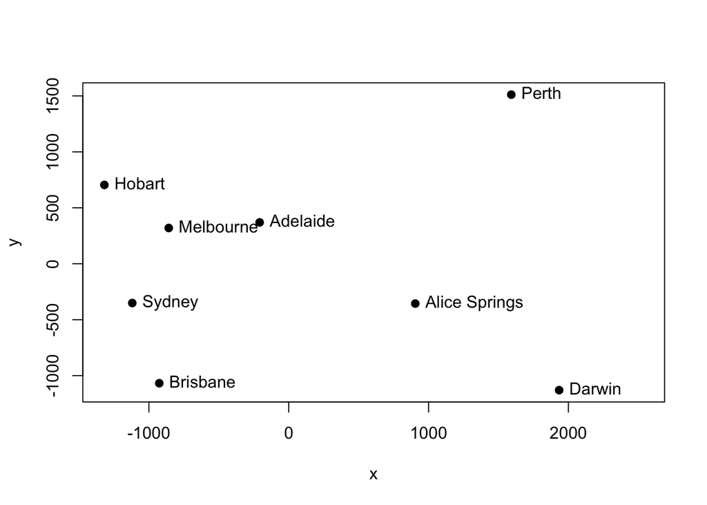

```r
fit <- cmdscale(dist.au[, -1], eig = TRUE, k = 2)
x <- fit$points[, 1]
y <- fit$points[, 2]
plot(x, y, pch = 19, xlim = range(x) + c(0, 600))
city.names <- c("Adelaide", "Alice Springs", "Brisbane", "Darwin", "Hobart",
                "Melbourne", "Perth", "Sydney")
text(x, y, pos = 4, labels = city.names)
```

El siguiente ejemplo implementa el mismo método tomando ahora datos de distancias entre distintas ciudades de Europa.

```r
euromat <-  as.matrix(eurodist)
euromat[1:5,1:5]
```

```
##           Athens Barcelona Brussels Calais Cherbourg
## Athens         0      3313     2963   3175      3339
## Barcelona   3313         0     1318   1326      1294
## Brussels    2963      1318        0    204       583
## Calais      3175      1326      204      0       460
## Cherbourg   3339      1294      583    460         0
```

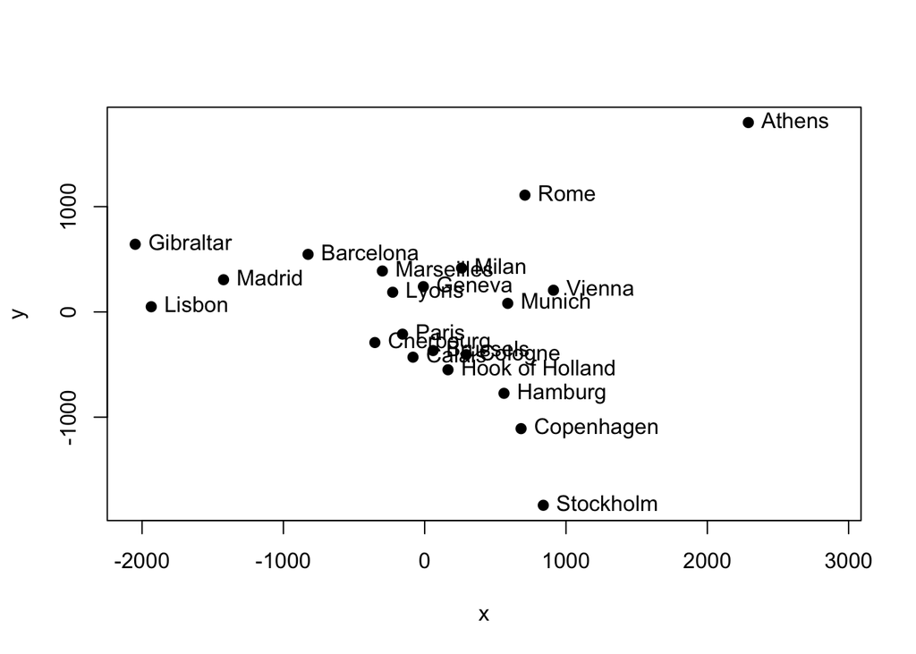

```r
# CMDSCALE
fit <- cmdscale(euromat, eig = TRUE, k = 2)
x <- fit$points[, 1]
y <- fit$points[, 2]

plot(x, y, pch = 19, xlim = range(x) + c(0, 600))
text(x, y, pos = 4, labels = labels(eurodist))
```

Ahora ocupando los mismos datos, se implementa el MDS paso por paso.

Empezamos con la matriz de distancias que teniamos en el ejemplo anterior. Se genera la matriz centradora kn.

```r
dim(euromat)
```

```
## [1] 21 21
```

```r
d <- euromat
n <- nrow(d)
kn <- diag(1, n) - (1/n)*rep(1, n)*rep(1, n)
dim(d)
```

```
## [1] 21 21
```

```r
dim(kn)
```

```
## [1] 21 21
```

Centramos la matriz de distancias al cuadrado, por filas y por columnas y obtenemos B.
$$B=\frac{-1}{2}k_nD^2k_n$$

```r
b <- (-1/2) *((kn %*% d^2) %*% kn)
```

Sabemos que:
$$B=XX^T$$
Por lo tanto teniendo B podemos obtener X usando el método de descomposición espectral. Primero se obtienen los eigenvalores y eigenvectores de B tomando k eigenvectores y eigenvalores. P es la matriz de eigenvectores y C la matriz de eigenvalores.

$$P=[V_1, V_2, |...| , V_k] \hspace{2cm} \lambda_1\geq\lambda_2\geq...\geq\lambda_k
\hspace{2cm}
C=\begin{bmatrix}
\lambda_1 & \dots & 0 \\
\dots & \dots & \dots \\
0 & \dots & \lambda_n
\end{bmatrix}$$

```r
eigenval <- eigen(b)
c <-  diag(eigenval$values)
p <-  eigenval$vectors
```

De acuerdo a la demostración vista en clase sabemos que:

$$X= PC^{1/2}= [V_1, V_2, |...| , V_n] \begin{bmatrix}
\sqrt\lambda_1 & \dots & 0 \\
\dots & \dots & \dots \\
0 & \dots & \sqrt\lambda_n
\end{bmatrix}=[\sqrt\lambda_1V_1, \sqrt\lambda_2V_2,|...|, \sqrt\lambda_nV_n ]$$
Suponemos que:
$$\lambda_1\geq\lambda_2\geq...\geq\lambda_n$$
Entonces:
$$\hat{X}==[\sqrt\lambda_1V_1, \sqrt\lambda_2V_2,|...|, \sqrt\lambda_kV_k ]$$
es una aproximación de grado k de X si
$$k\leq n$$

```r
fit$eig
```

```
##  [1]  1.953838e+07  1.185656e+07  1.528844e+06  1.118742e+06  7.893472e+05
##  [6]  5.816552e+05  2.623192e+05  1.925976e+05  1.450845e+05  1.079673e+05
## [11]  5.139484e+04 -3.259629e-09 -9.496124e+03 -5.305820e+04 -1.322166e+05
## [16] -2.573360e+05 -3.326719e+05 -5.162523e+05 -9.191491e+05 -1.006504e+06
## [21] -2.251844e+06
```

```r
eigenval$values
```

```
##  [1]  1.953838e+07  1.185656e+07  1.528844e+06  1.118742e+06  7.893472e+05
##  [6]  5.816552e+05  2.623192e+05  1.925976e+05  1.450845e+05  1.079673e+05
## [11]  5.139484e+04 -1.396984e-09 -9.496124e+03 -5.305820e+04 -1.322166e+05
## [16] -2.573360e+05 -3.326719e+05 -5.162523e+05 -9.191491e+05 -1.006504e+06
## [21] -2.251844e+06
```

```r
aprox <- p %*% sqrt( abs(c) ) %>%
  as_tibble()
```

Graficamos nuestra aproximación de X y esperamos obtener una visualización parecida que con el método cmdscale.

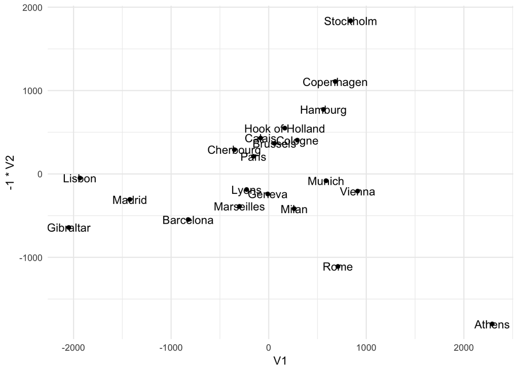

```r
ggplot(aprox, aes(x = V1, y = -1*V2)) +
  geom_point() +
  geom_text(label = rownames(d))
```

Ahora aplicaremos los mismos pasos al set de datos de senadores en México. Primero importamos y limpiamos los datos.

```r
library(metodosMultivariados2017)
data("senado_votaciones")
names(senado_votaciones)
```

```
##   [1] "FECHA"
##   [2] "ASUNTO"
##   [3] "HREF"
##   [4] "ACOSTA ISLAS ANABEL"
##   [5] "ALBARRAN MENDOZA ESTEBAN"
##   [6] "ALBORES GLEASON ROBERTO ARMANDO"
##   [7] "ALCALA RUIZ BLANCA MARIA DEL SOCORRO"
##   [8] "ALVAREZ GARCIA IVONNE LILIANA"
##   [9] "AMADOR GAXIOLA DANIEL"
##  [10] "ARAUJO LARA ANGELICA DEL ROSARIO"
##  [11] "ARECHIGA AVILA JORGE"
##  [12] "AVILA RUIZ DANIEL GABRIEL"
##  [13] "AYALA ALMEIDA JOEL"
##  [14] "BARBOSA HUERTA MIGUEL"
##  [15] "BARRERA TAPIA MARIA ELENA"
```

[output cut: 120 more lines]

```r
dim(senado_votaciones)
```

```
## [1] 115 135
```

```r
# setwd("/home/lmalpica/Desktop/itam-semestre2/mauricio")
aux.senadores <- read.csv("../data/senadores-partidos.csv", header = FALSE,
                          col.names = c("senador", "partido", "estado")) %>%
  mutate(partido = str_trim(partido))
sort(colnames(senado_votaciones)[-1:-3])
```

```
##   [1] "ACOSTA ISLAS ANABEL"
##   [2] "ALBARRAN MENDOZA ESTEBAN"
##   [3] "ALBORES GLEASON ROBERTO ARMANDO"
##   [4] "ALCALA RUIZ BLANCA MARIA DEL SOCORRO"
##   [5] "ALVAREZ GARCIA IVONNE LILIANA"
##   [6] "AMADOR GAXIOLA DANIEL"
##   [7] "ARAUJO LARA ANGELICA DEL ROSARIO"
##   [8] "ARECHIGA AVILA JORGE"
##   [9] "AVILA RUIZ DANIEL GABRIEL"
##  [10] "AYALA ALMEIDA JOEL"
##  [11] "BARBOSA HUERTA MIGUEL"
##  [12] "BARRERA TAPIA MARIA ELENA"
##  [13] "BARROSO AGRAMONT RICARDO"
##  [14] "BARTLETT DIAZ MANUEL"
##  [15] "BERISTAIN NAVARRETE LUZ MARIA"
```

[output cut: 117 more lines]

```r
sort(as.character(str_trim(aux.senadores$senador)))
```

```
##   [1] "ACOSTA ISLAS ANABEL"
##   [2] "ALBARRAN MENDOZA ESTEBAN"
##   [3] "ALBORES GLEASON ROBERTO ARMANDO"
##   [4] "ALCALA RUIZ BLANCA MARIA DEL SOCORRO"
##   [5] "ALVAREZ GARCIA IVONNE LILIANA"
##   [6] "AMADOR GAXIOLA DANIEL"
##   [7] "ARAUJO LARA ANGELICA DEL ROSARIO"
##   [8] "ARECHIGA AVILA JORGE"
##   [9] "AVILA RUIZ DANIEL GABRIEL"
##  [10] "AYALA ALMEIDA JOEL"
##  [11] "BARBOSA HUERTA MIGUEL"
##  [12] "BARRERA TAPIA MARIA ELENA"
##  [13] "BARROSO AGRAMONT RICARDO"
##  [14] "BARTLETT DIAZ MANUEL"
##  [15] "BERISTAIN NAVARRETE LUZ MARIA"
```

[output cut: 117 more lines]

```r
tab.senadores <- data.frame(
  senador = colnames(senado_votaciones)[-1:-3]
  ) %>%
  left_join(aux.senadores, by = "senador") %>%
  mutate(senador.id = row.names(.),
         partido = str_replace_all(partido, "ṔAN", "PAN"))
head(tab.senadores)
```

```
##                                senador partido     estado senador.id
## 1                  ACOSTA ISLAS ANABEL     PRI     Sonora          1
## 2             ALBARRAN MENDOZA ESTEBAN     PRI   Guerrero          2
## 3      ALBORES GLEASON ROBERTO ARMANDO     PRI    Chiapas          3
## 4 ALCALA RUIZ BLANCA MARIA DEL SOCORRO     PRI    Puebla           4
## 5        ALVAREZ GARCIA IVONNE LILIANA     PRI Nuevo Leon          5
## 6                AMADOR GAXIOLA DANIEL     PRI    Sinaloa          6
```

Función que elimina los NA (los NA se deben a las ausencias).

```r
NAReplace <- function(col){
  col2 <- ifelse(is.na(col), 99, col)
  return(col2)
}
```

MDS.

Primero obtenemos la matriz de distancias entre iniciativas, ésta está dada por la similitud entre los votos que han emitido los senadores para las distintas iniciativas.

```r
# PROPUESTA
d <- senado_votaciones %>%
  dplyr::select(-1:-3) %>%
  # t() %>%
  as_tibble() %>%
  mutate_all(funs(NAReplace(.))) %>%
  dist(method = "euclidean") %>%
  as.matrix()
```

Ya que obtuvimos la matriz de distancias repetimos los pasos ilustrados anteriormente y obtenemos la aproximación de X.

```r
n <- nrow(d)
kn <- diag(1, n) - (1/n)*rep(1, n)*rep(1, n)

dim(d)
```

```
## [1] 115 115
```

```r
dim(kn)
```

```
## [1] 115 115
```

```r
b <- (-1/2) *((kn %*% d^2) %*% kn)

eigenval <- eigen(b)
c <-  diag(eigenval$values)
p <-  eigenval$vectors
eigenval$values
```

```
##   [1]  2.767712e+06  1.943157e+06  1.622568e+06  1.343493e+06  1.276623e+06
##   [6]  1.093217e+06  9.178435e+05  8.649373e+05  8.477699e+05  7.924194e+05
##  [11]  7.332389e+05  6.893226e+05  6.605618e+05  5.910362e+05  5.585037e+05
##  [16]  5.353526e+05  4.839704e+05  4.738860e+05  4.553643e+05  4.255220e+05
##  [21]  4.006584e+05  3.825261e+05  3.566170e+05  3.392009e+05  3.274339e+05
##  [26]  3.196546e+05  2.898520e+05  2.763456e+05  2.668123e+05  2.547715e+05
##  [31]  2.503492e+05  2.346769e+05  2.269869e+05  2.228666e+05  1.996541e+05
##  [36]  1.910313e+05  1.896332e+05  1.822447e+05  1.691013e+05  1.636773e+05
##  [41]  1.572128e+05  1.531175e+05  1.447065e+05  1.381886e+05  1.344629e+05
##  [46]  1.241731e+05  1.190201e+05  1.155971e+05  1.120876e+05  1.061157e+05
##  [51]  1.033308e+05  1.007740e+05  9.974063e+04  9.349976e+04  8.877581e+04
##  [56]  8.498641e+04  8.024244e+04  7.718293e+04  7.362959e+04  7.012424e+04
##  [61]  6.809411e+04  6.683622e+04  6.258137e+04  6.005902e+04  5.833965e+04
##  [66]  5.566770e+04  5.292893e+04  4.980628e+04  4.595696e+04  4.251500e+04
##  [71]  4.227632e+04  4.199075e+04  4.054882e+04  3.834882e+04  3.796536e+04
##  [76]  3.359679e+04  3.183146e+04  2.906970e+04  2.827865e+04  2.698578e+04
##  [81]  2.656083e+04  2.421436e+04  2.274918e+04  2.129095e+04  1.997057e+04
##  [86]  1.942683e+04  1.783142e+04  1.584830e+04  1.463947e+04  1.387732e+04
##  [91]  1.280391e+04  1.209441e+04  1.169917e+04  1.032056e+04  9.460632e+03
##  [96]  8.819626e+03  7.514313e+03  6.722144e+03  6.576146e+03  6.417414e+03
## [101]  6.003315e+03  5.173120e+03  5.020154e+03  3.896944e+03  3.786547e+03
## [106]  2.962916e+03  2.180565e+03  1.793514e+03  1.763231e+03  1.510593e+03
## [111]  1.261563e+03  1.046358e+03  5.046888e+02  3.755361e+02 -2.424274e-10
```

```r
aprox <- p %*% sqrt( abs(c) ) %>%
  as_tibble()
```

Con el resultado obtenido graficamos las distancias entre iniciativas y lo visualizamos de acuerdo a las fechas en las que fueron votadas.

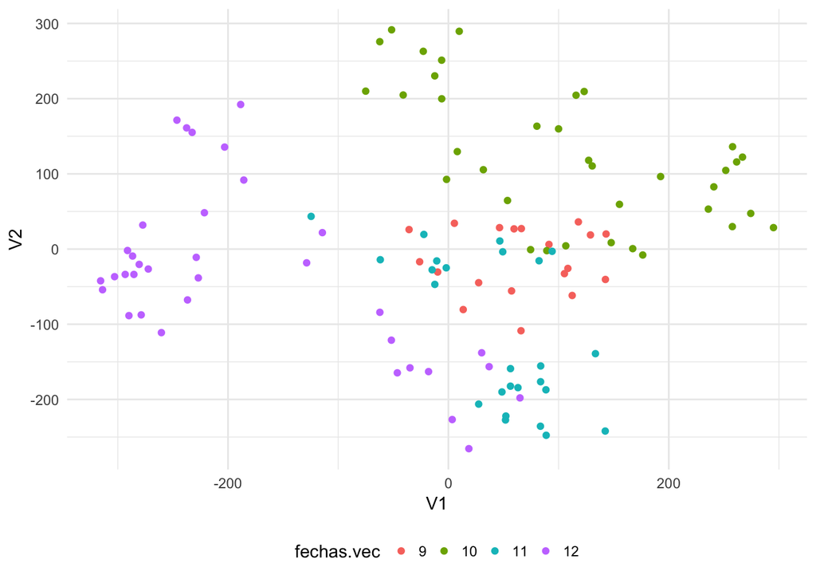

```r
fechas.vec <- factor(month(senado_votaciones$FECHA))
ggplot(aprox, aes(x = V1, y = V2)) +
  geom_point(aes(color = fechas.vec) )  +
  theme(legend.position = 'bottom')
```

```r
# geom_text(label = cnames(senado_votaciones)[-1:-3], check_overlap = T)
```

Hacemos el MDS con la función de R y comparamos los resultados obtenidos.

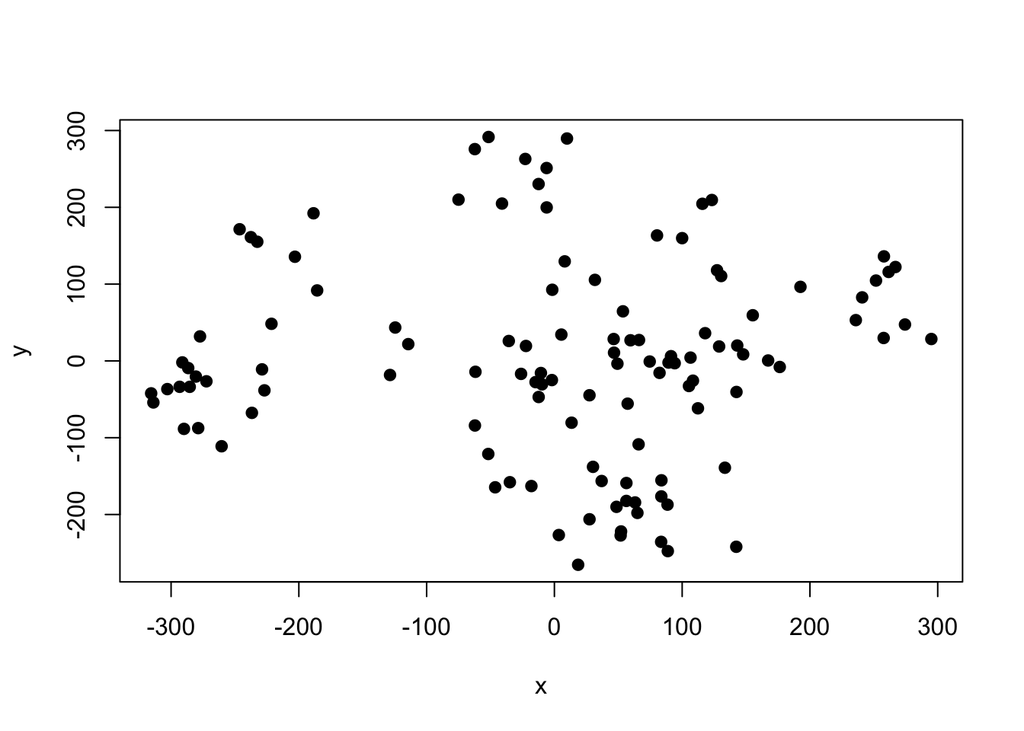

```r
fit <- cmdscale(d, eig = TRUE, k = 2)
x <- fit$points[, 1]
y <- fit$points[, 2]
plot(x, y, pch = 19)
```

Ahora aplicaremos el mismo análisis pero tomando como objetos a los senadores en vez de las iniciativas, la distancia entre ellos depende de que tan similares sean sus votaciones para las distintas iniciativas. Primero obtenemos los datos y obtenemos la matriz de distancias.

```r
d <- senado_votaciones %>%
  dplyr::select(-1:-3) %>%
  t() %>%
  as_tibble() %>%
  mutate_all(funs(NAReplace(.))) %>%
  dist(method = "euclidean") %>%
  as.matrix()
```

Hacemos el MDS.

```r
n <- nrow(d)
kn <- diag(1, n) - (1/n)*rep(1, n)*rep(1, n)

dim(d)
```

```
## [1] 132 132
```

```r
dim(kn)
```

```
## [1] 132 132
```

```r
b <- (-1/2) *((kn %*% d^2) %*% kn)

eigenval <- eigen(b)
c <-  diag(eigenval$values)
p <-  eigenval$vectors
eigenval$values
```

```
##   [1]  7.226845e+06  2.730978e+06  1.900156e+06  1.566928e+06  1.291614e+06
##   [6]  1.244604e+06  1.078727e+06  9.165104e+05  8.539099e+05  8.268353e+05
##  [11]  7.774946e+05  7.249058e+05  6.590470e+05  6.337920e+05  5.622018e+05
##  [16]  5.532300e+05  5.273531e+05  4.783418e+05  4.539559e+05  4.241998e+05
##  [21]  3.960367e+05  3.852497e+05  3.618575e+05  3.485072e+05  3.363900e+05
##  [26]  3.214531e+05  3.077733e+05  2.764432e+05  2.667671e+05  2.659467e+05
##  [31]  2.513752e+05  2.435547e+05  2.277254e+05  2.218237e+05  2.143399e+05
##  [36]  1.991546e+05  1.898131e+05  1.840904e+05  1.741554e+05  1.684318e+05
##  [41]  1.600769e+05  1.534417e+05  1.488672e+05  1.435219e+05  1.337604e+05
##  [46]  1.303711e+05  1.241707e+05  1.160334e+05  1.134752e+05  1.099232e+05
##  [51]  1.038815e+05  1.023734e+05  9.973335e+04  9.706620e+04  9.101808e+04
##  [56]  8.751108e+04  8.325846e+04  7.847590e+04  7.683615e+04  7.261919e+04
##  [61]  7.011198e+04  6.746123e+04  6.506871e+04  6.214997e+04  5.933137e+04
##  [66]  5.663586e+04  5.544762e+04  4.913508e+04  4.788945e+04  4.412667e+04
##  [71]  4.240591e+04  4.161342e+04  4.024348e+04  3.826346e+04  3.675247e+04
##  [76]  3.449255e+04  3.304252e+04  3.074631e+04  2.890125e+04  2.797667e+04
##  [81]  2.644313e+04  2.555676e+04  2.343417e+04  2.243432e+04  2.046912e+04
##  [86]  1.964462e+04  1.809327e+04  1.654995e+04  1.490537e+04  1.402482e+04
##  [91]  1.308049e+04  1.234309e+04  1.152979e+04  1.057094e+04  9.737006e+03
##  [96]  9.156323e+03  8.759276e+03  7.251314e+03  6.651788e+03  6.529864e+03
## [101]  5.754558e+03  5.309442e+03  5.058593e+03  4.345134e+03  3.818365e+03
## [106]  3.494478e+03  2.677807e+03  1.954205e+03  1.688964e+03  1.485028e+03
## [111]  1.419210e+03  1.245689e+03  9.382085e+02  4.925007e+02  3.690811e+02
## [116]  3.215008e-10  2.826709e-10  1.174402e-10  1.106042e-10  9.218453e-11
## [121]  5.238703e-11  1.878759e-11  7.829437e-12  2.755681e-12 -1.635470e-11
## [126] -5.254907e-11 -5.623487e-11 -6.950537e-11 -8.463635e-11 -1.202264e-10
## [131] -1.732819e-10 -4.247444e-10
```

```r
aprox <- p %*% sqrt( abs(c) )
```

Hacemos una gráfica del resultado obtenido y visualizamos a los senadores por partido al que pertenecen.

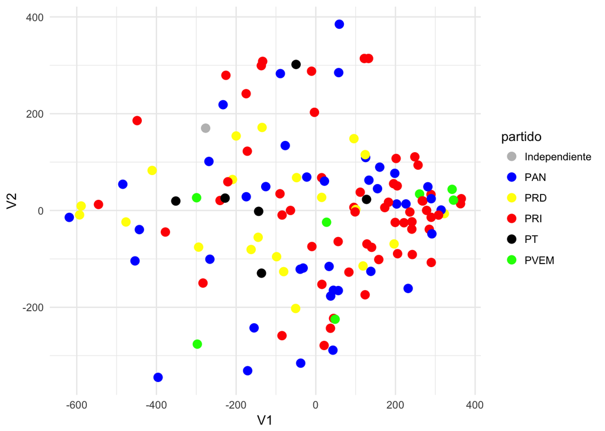

```r
tab.gg <- aprox %>%
  as_tibble() %>%
  mutate(senador.id = row.names(.)) %>%
  left_join(tab.senadores, by = 'senador.id')


ggplot(tab.gg, aes(x = V1, y = V2, color = partido)) +
  geom_point(size = 3) +
  scale_color_manual(values = c("gray", "blue", "yellow", "red", "black", "green"))
```

Repetimos el análisis con la función cmdscale.

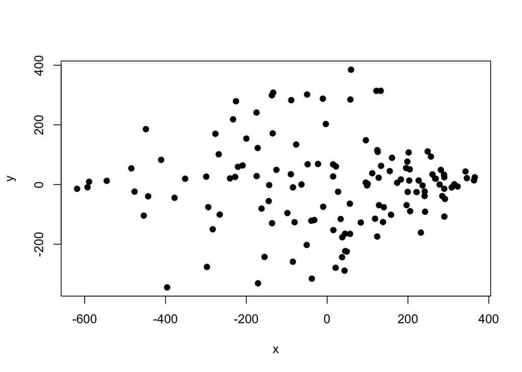

```r
# CMDSCALE
fit <- cmdscale(d, eig = TRUE, k = 2)
x <- fit$points[, 1]
y <- fit$points[, 2]
plot(x, y, pch = 19)
```

Como podemos ver no hay una agrupación clara entre los senadores de acuerdo al partido al que pertenecen. Sin embargo si se puede ver un grupo bien delimitado compuesto principalmente por senadores del PAN, del PRI y del PVEM, también se puede ver que los puntos más aislados en la gráfica son en su mayoría senadores del PAN y del PRD. Sería interesante buscar por nombre a los senadores que pertenecen al grupo más delimitado y ver que relación hay entre ellos, si son figuras líderes en sus partidos o si pertenecen a estados cercanos geográficamente.